# OMICsPCA: An R package for quantitative integration and analysis of multiple omics assays from heterogeneous samples

Subhadeep Das

2018-08-21

# 1 Introduction

## 1.1 Background:

OMICsPCA is a statistical framework designed to integrate and analyse multiple types of heterogeneous assays, factors, data types or modalities (e.g. ChIP-seq, RNA-seq) from different samples or sources ( e.g. multiple cell lines, time points etc.). Biological processes in eukaryotes are complicated molecular interactions, spanned over multiple layers of regulation. In order to understand the collective effects of the interactions of biological processes, they should be studied parallelly. High throughput sequencing has enabled genome-wide assays across several disease conditions, cell types, time points etc. at a much faster rate. On the other hand, replicated experiments on diverse samples (e.g. various cell lines) help us to understand the origin of variation (e.g. the genes, TSSs, exons etc) observed between the samples. Therefore, integrative multi-omics studies on heterogeneous samples are gaining their importance every day. As a consequence, a huge number of datasets are being produced and stored in public databases, allowing researchers to perform integrative analysis of multiple data modalities.

Unfortunately, most of such studies are limited to very few samples(e.g. cell lines) or data modalities (e.g. various ChIP-seq assays) due to the huge cost, ethical issues, and scarcity of samples associated with the entire experimental process. And, most of the data integration methods rely on the condition of homogeneity of samples, i.e. the samples corresponding to each modality should be the same. As a result, integrative analysis on publicly available data sets is very much rare and extremely restricted to very few numbers of samples or modalities (or both).

## 1.2 Illustration of the problem with example

Let’s illustrate the problem with an example. Suppose our objective is to decipher the collective effect of CpG methylation and H3k4me3 histone modification on the gene expression, followed by clustering of the similar genes on the basis of the consolidated effect of these 2 data modalities. Consider we have the following datasets:

1. CpG methylation on 5 Cell lines A, B, C, D, and E
2. H3k4me3 histone modification on 10 Cell lines A,D,E,I,K,Q,P,Z,W and G.

Here, we can not calculate the collective effect directly, since the cell lines and the number of cell lines are different in the two experiments.

## 1.3 Previous approaches/frameworks towards multi-omics data integration

Several data integration frameworks have been designed over the past few years to overcome such difficulty. For example, Huang (1) proposed a regression-based joint modeling approach to integrate SNPs, DNA methylation, and gene expression; He et al. (2)developed a pattern matching method to integrated eQTL and GWAS data; Xiong et al. (3) developed a statistical framework to associate SNP and gene expression information etc. All such applications are designed to perform in a supervised manner, i.e. the integrated data modalities must be associated with labelled classes (e.g. disease and control class; pathway 1 and pathway 2 etc.). Such constraints impose a limitation on the algorithms to be used in varieties of applications (e.g., can’t be used in clustering). In contrast, Ha, et al. (4) developed an unsupervised Gaussian process model for qualitative (logical combination of binary values, e.g. 0/1 or TRUE/FALSE) integration of a large number of epigenetic factors and applied it to describe cell lineage-specific gene regulatory programs. Although this overcomes the limitation of class association to some extent, this process is only sufficient for the applications where qualitative integration is sufficient.

As mentioned earlier, there is another important application of data integration, which is associated with the disentanglement of the source of variation observed between the samples or the individuals. A common strategy used in such studies is to perform a large number of association tests between the features and the data modalities (5, 6). Alternatively, kernel or graph-based methods are also considered as methods of integration and the integrated data is then used to build common similarity networks between samples (7, 8). Although effective in accomplishing specific tasks, such approaches lack proper interpretability (9) and do not suffice to explain many other relevant queries applicable to integrated omics data. Such queries include identification of variably controlled genes, genes sharing similar epigenomic state across various samples and many more.

## 1.4 OMICsPCA

OMICsPCA is a multipurpose tool designed to overcome the difficulties associated with both the applications of data integration. It is designed to identify the source of variation among the samples/variables (the columns of a table, e.g. cell lines, patients etc.) or individuals (the rows of a table, e.g. genes, exons etc.) associated with each data modality (i.e. the tables, e.g. CpG_methylation, ChIP-seq on a protein etc.). It guides the user through various analyses to decide on similar samples/variables (e.g.Cell lines). This is followed by selecting the data modalities (e.g. the assays) that can be included or excluded leading to data integration. The selected data modalities can be further integrated and analysed and the data points or individuals (e.g. genes, TSSs, exons) may be clustered on the basis of the integrated data coming from single or multiple modalities.

In short, OMICsPCA can be used in clustering genes, TSSs, exons on the basis of multiple types of heterogeneous experimental or theoretical data or vice-versa. Such kind of multivariate analyses is useful in identification of similar cell lines or assays prior to the integration process. In this vignette, we show an example of the entire analysis process done on human transcription start sites.

Here is a flowchart of the overall functionality of the functions of OMICsPCA and their arguments

```
#   format width height colorspace matte filesize density
# 1    PNG  3313   2563       sRGB  TRUE        0   72x72
```

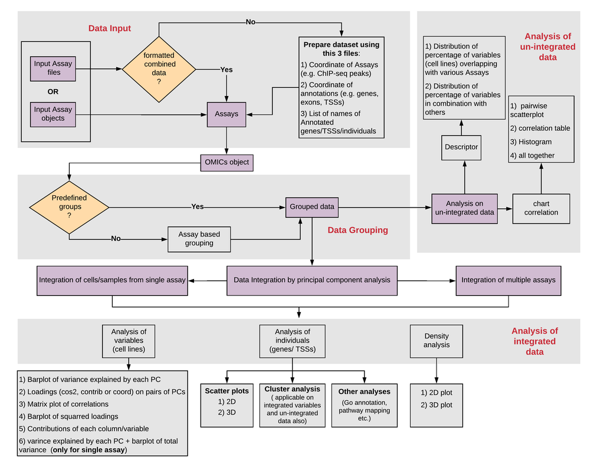

# 2 DATA

Summary of data sets

| Assay | Assay Type | Number of Cell lines | Name of cell lines | Experiment |
| --- | --- | --- | --- | --- |
| CAGE | Location of tag clusters | 31 | A549 ,AG04450 ,B.Cells_CD20. ,BJ ,Gm12878 ,H1.hESC ,HAoAF ,HAoEC ,HCH ,HeLaS3 ,HepG2 ,HFDPC ,hMSC.AT ,hMSC.BM ,hMSC.UC ,HOB ,HPC.PL ,HPIEpC ,HSaVEC ,HUVEC ,HVMF ,HWP ,IMR90 ,K562 ,MCF7 ,Monocytes.CD14… | Cap Analysis of Gene Expression |
| H2az | location of Histone modification peaks | 5 | Gm12878 ,Hepg2 ,Hsmm ,K562 ,Osteobl | ChIP-seq |
| H3k9ac | location of Histone modification peaks | 13 | Gm12878 ,H1hesc ,Helas3 ,Hepg2 ,Hmec ,Hsmm ,Hsmmt ,Huvec ,K562 ,Nhdfad ,Nhek ,Nhlf ,Nt2d1 | ChIP-seq |
| H3k9me3 | location of Histone modification peaks | 6 | Gm12878 ,Hsmm ,K562 ,Osteobl ,Nt2d1 ,U2os | ChIP-seq |
| H3k4me1 | location of Histone modification peaks | 12 | Gm12878 ,H1hesc ,Hmec ,Hsmm ,Hsmmt ,Huvec ,K562 ,Nha ,Nhek ,Nhlf ,Osteobl ,Nt2d1 | ChIP-seq |
| H3k4me2 | location of Histone modification peaks | 13 | Gm12878 ,H1hesc ,Helas3 ,Hepg2 ,Hmec ,Hsmm ,Hsmmt ,Huvec ,K562 ,Nhdfad ,Nhek ,Nhlf ,Osteobl | ChIP-seq |
| H3k27ac | location of Histone modification peaks | 14 | Gm12878 ,H1hesc ,Helas3 ,Hepg2 ,Hmec ,Hsmm ,Hsmmt ,Huvec ,K562 ,Nha ,Nhdfad ,Nhek ,Nhlf ,Osteobl | ChIP-seq |
| H3k27me3 | location of Histone modification peaks | 20 | Huvec ,Nha ,Nhdfad ,Nhek ,Nhlf ,Gm12878 ,H1hesc ,Helas3 ,Hepg2 ,Hmec ,Hsmm ,H7es ,Hre ,K562 ,Nt2d1 ,Bj ,Caco2 ,Gm06990 ,Saec ,Sknshra | ChIP-seq |
| H3k79me2 | location of Histone modification peaks | 6 | Gm12878 ,Helas3 ,Hepg2 ,Hsmm ,Hsmmt ,K562 | ChIP-seq |
| H4k20me1 | location of Histone modification peaks | 11 | Gm12878 ,H1hesc ,Helas3 ,Hepg2 ,Hmec ,Hsmm ,Hsmmt ,Huvec ,K562 ,Nhek ,Nhlf | ChIP-seq |
| DNase hypersensitivity | location of DNase I hypersensitive sites | 35 | X8988T ,AoSMC ,Chorion ,CLL ,Fibrobl ,FibroP ,Gliobla ,Gm12878 ,GM18507 ,H1.hESC ,H9ES ,HeLaS3IFNa4h ,Hepatocytes ,HPDE6E6E7 ,HSMMemb ,HTR8svn ,Huh7 ,iPS ,IshikawaEstradiol ,K562 ,LNCaPAndrogen ,MCF7H… | DNaseI hypersensitivity |

# 3 Example

In this section we demonstrate the functionality of OMICsPCA with an example. We divided the GENCODE annotated TSSs into 4 groups on the basis of their on-off state in 31 cell lines and mapped ChIP-seq, DNA methylation, DNase I hypersensitivity data with them in order to study the consolidated effect of these data modalities on their expression. Before calculating the consolidated effect, we filtered out the outlier samples and identified the data modalities that show discriminatory density pattern among the expression groups. Finally, we clustered the similar TSSs together on the basis of the consolidated effect of discriminatory factors.

## 3.1 Preparation of data

OMICsPCA has an inbuilt function **prepareDataset()** that aggregates the samples (e.g. cell lines) of each data modality (e.g. a histone modification ChIP-seq assay) corresponding to each feature of the genome (notably gene, TSS, exon etc.) and returns a dataframe.

The rows of this dataframe object contain the features (e.g. genes) and each column contains the values corresponding to a sample (e.g. Cell line).

The arguments taken by this function is described below:

1. `factdir`: full path of the directory containing files corresponding to various cell lines in .bed format. This directory should contain only the files of the same assay (modality) (e.g. H3k9ac) from different samples (e.g. cell lines).
2. `annofile`: full path of the file containing the annotation file (e.g exons, TSSs, genes etc) in .bed format.
3. `annolist`: name of full set or subset of the entries in the annotation file. The **.bed** files should have at least 4 columns. The first column is the chromosome name, the second and third is the start and end position of the feature (e.g. a gene or a ChIP-seq peak etc). The fourth column contains the value of the described feature (e.g. expression of a gene, the ChIP-seq intensity of a peak or name of a gene etc.).

The `.bed` files should have at least 4 columns. The first column is the chromosome name, the second and third is the start and end of the feature (e.g. a gene or a ChIP-seq peak etc) accordingly and the fourth column contains the value (e.g. expression of a gene, ChIP-seq intensity of a peak or name of a gene etc.).

Some examples of the input file formats are given below:

Intensity of ChIP-seq peaks of H3k27ac in Gm12878 Cell line

| chromosome | start | end | intensity |
| --- | --- | --- | --- |
| chr1 | 713109 | 715355 | 5.660025 |
| chr1 | 760948 | 763296 | 5.101740 |
| chr1 | 843748 | 844210 | 2.029560 |
| chr1 | 875463 | 875860 | 4.769479 |
| chr1 | 893627 | 894938 | 4.789376 |

annotation file of Human transcription start sites of assembly hg19 (`annofile`)

| chromosome | start | end | TSS ID |
| --- | --- | --- | --- |
| chr1 | 11858 | 11885 | ENST00000456328.2;ENST00000515242.2;ENST00000518655.2 |
| chr1 | 11999 | 12021 | ENST00000450305.2 |
| chr1 | 29543 | 29565 | ENST00000473358.1 |
| chr1 | 30256 | 30278 | ENST00000469289.1 |
| chr1 | 53038 | 53060 | ENST00000594647.1 |

names of the human TSSs of assembly hg19 (`annolist`)

| GENCODE ID |
| --- |
| ENST00000387347.2 |
| ENST00000387314.1 |
| ENST00000389680.2 |
| ENST00000386347.1 |
| ENST00000361390.2 |

Here we show the use of **prpareDataset()** by integrating H2az ChIP-seq peaks from 5 cell lines into a data frame named “H2az”. The example data sets are packaged inside the `OMICsPCAdata` package

```r
anno <- system.file("extdata/annotation/TSS_groups.bed",
package = "OMICsPCAdata")

list <- system.file("extdata/annotation/GENCODE_list",
package = "OMICsPCAdata")

fact <- system.file("extdata/factors/H2az",
package = "OMICsPCAdata")

list.files(path = fact)
# [1] "Gm12878.bed" "Hepg2.bed"   "Hsmm.bed"    "K562.bed"    "Osteobl.bed"
```

prepareDataset() will combine these 5 cell lines into a dataframe. The rows of the dataframe will correspond to the entries in file entered through the variable named `list` and the columns will correspond to the 5 cell lines shown above.

```r
H2az_all_cells <- prepareDataset(factdir = fact,
annofile = anno, annolist = list)

head(H2az_all_cells, n = 4)
```

[output not shown]

For a different assay type repeat the process:

```
factor_x  <- prepareDataset(factdir = fact,
annofile = anno, annolist = list)

# where `fact` is the directory of the samples corresponding to factor_x

For example,

fact <- system.file("path to cpg")
cpg <- prepareDataset(factdir = fact, annofile=anno, annolist = list)
```

## 3.2 Reading data

OMICsPCA is designed to read various assays done on various cell lines into an user-defined S4 variable and then run various analyses on this object. The class of this S4 object is predefined as **OMICS** and a constructor function in this name is provided to create an object of class **OMICS**. For ease of analysis, we compiled some preloaded data similar to the output of prepareData() into the supporting package OMICsPCAdata().

The data is read to the **InputAssays** slot of the “OMICS” object by the function InputOMICs. It can read object directly from the environment or from a file.

### 3.2.1 Reading from objects

If the objects are present in the global environment, we can directly read them.

```r
library(OMICsPCAdata)

# creating an object of class "OMICs" using the constructor
#function OMICS()

OMICsdata <- OMICs()

str(OMICsdata)
# Formal class 'OMICs' [package "OMICsPCA"] with 4 slots
#   ..@ InputAssays  : list()
#   ..@ groups       : list()
#   ..@ PCA          : list()
#   ..@ integratedPCA: list()

Assays <- c("CAGE_Cell_wise_v2",
            "DHS_len_Cell_wise",
            "H2az_Cell_wise",
            "H3k27ac_Cell_wise",
            "H3k27me3_Cell_wise",
            "H3k4me1_Cell_wise",
            "H3k4me2_Cell_wise",
            "H3k79me2_Cell_wise",
            "H3k9ac_Cell_wise",
            "H3k9me3_Cell_wise",
            "H4k20me1_Cell_wise")

### reading data into OMICsdata object
InputOMICs(name = "OMICsdata", Assays = Assays)
```

### 3.2.2 Reading from files

To read from a file we need to pass an additional argument path and set `typeisfile` to TRUE. By default, `typeisfile` is set to FALSE . The `path` argument should contain the path to the directory containing files to be read.

```r
Assays <- c("CAGE_Cell_wise_v2",
            "DHS_len_Cell_wise",
            "H2az_Cell_wise",
            "H3k27ac_Cell_wise",
            "H3k27me3_Cell_wise",
            "H3k4me1_Cell_wise",
            "H3k4me2_Cell_wise",
            "H3k79me2_Cell_wise",
            "H3k9ac_Cell_wise",
            "H3k9me3_Cell_wise",
            "H4k20me1_Cell_wise")
path = system.file("extdata/rawdata", package = "OMICsPCAdata")

### reading data into OMICsdata object
InputOMICs(name = "OMICsdata", Assays = Assays, typeisfile = TRUE,
path = path)
```

## 3.3 Subsetting into groups

Once the dataframes corresponding to the assays/modalities is prepared, the user may want to divide the entire annotation set into smaller groups. Here we show an example to divide 154301 GENCODE TSS groups into 4 expression groups. The grouping criteria are based on the on/off status (determined from CAGE experiments) of the TSSs in 31 cell lines.

1. **group_names** : a vector containing the user-defined names of the groups to be created
2. **factor** : name of the data frame on which groups will be created
3. **comparison** : a vector of comparison symbols such as >, <, ==, >=, <=, %in% etc
4. **condition** : a vector of conditions corresponding to `comparison`. condition should be a vector or range of digits (e.g. c(1,3,7,9) or 1:5) if %in% is chosen as comparison and a single digit for other cases.
5. **name** : name of the S4 object containing the assay data
6. **grouping_factor** : name of the dataframe on which grouping will be done

```r
create_group(name = "OMICsdata", group_names = c("WE" ,"RE" ,"NE" ,"IntE"),
grouping_factor = "CAGE_Cell_wise_v2",
comparison = c(">=" ,"%in%" ,"==" ,"%in%"),
condition = c("25" ,"1:5" ,"0" ,"6:24"))
```

In the above example the dataframe CAGE_Cell_wise_v2 is divided into 4 smaller data frames e.g; WE, RE, NE and IntE. “WE” contains TSSs expressed in >= 25 cell lines, “RE” represents TSSs expressed in 1 to 5 cell lines and so on.

The CAGE data frame looks like this:

|  | A549 | AG04450 | B.Cells_CD20. | BJ | Gm12878 |
| --- | --- | --- | --- | --- | --- |
| ENST00000387347.2 | 0 | 0 | 85.8895806558477 | 0 | 0 |
| ENST00000387314.1 | 49.6336910685519 | 0 | 0 | 0 | 0 |
| ENST00000389680.2 | 0 | 0 | 0 | 0 | 0 |
| ENST00000386347.1 | 61.4568108749758 | 19.4710468352727 | 23.969601604456 | 17.9526438211874 | 129.285323659344 |
| ENST00000361390.2 | 196.720325095994 | 121.562481593189 | 216.782580604901 | 60.083445046716 | 74.770012182987 |

**NOTE**: Running create_group is mandatory for all downstream data analyses. Even if there is no need to subset any assay to smaller groups. In such cases, do the following:

set

name = name of the “OMICS”" object;

group_names = “all”;

grouping factor = name of any Assay used in “InputOMICs”;

comparison = “>=”; condition = “0”

**create_group()** stores the smaller dataframes corresponding to the user-defined groups in the `groups` slot of `OMICsdata`.

**create_group()** can also read predefined groups. The predefined groups should be supplied as a data frame of a single column(containing the group names) and with row names through the argument `groupinfo` and the `predefinedgroups` argument should be set to “TRUE”. Here is an example:

```r
path <- system.file("extdata/groupinfo", package = "OMICsPCAdata")

groupinfo <- read.table(file = path, header = TRUE, row.names = 1,
sep ="\t", comment.char = "", stringsAsFactors = FALSE, quote = "")

head(groupinfo)
# # A tibble: 6 x 1
#   group
# * <chr>
# 1 WE
# 2 WE
# 3 WE
# 4 WE
# 5 WE
# 6 WE

create_group(name = "OMICsdata", predefinedgroups = TRUE,
groupinfo = groupinfo)
```

## 3.4 Exploratory data analysis (EDA) on created groups

Once the group information is read, we can study the the distribution of various Assays/factors(e.g. H2az, H3k9ac etc) on the annotations (e.g. TSSs, genes) of various groups (In the above example, the groups are created on the basis of on-off state of TSSs in 31 cell lines). OMICsPCA has several functions for EDA.

### 3.4.1 descriptor()

Descriptor works in two modes depending on the value passed through the argument `choice`. choice = 1 displays panels of boxplots corresponding to the Assay(s) or factor(s) or modality(ies) chosen through argument `factor`. Each panel shows a number of boxplots corresponding to the group(s) passed through argument `groups`. Each boxplot in choice 1 represents the distribution of the percentage of cell lines corresponding to a group that is overlapped with the selected assay.

**NOTE :** in `groups`, one group name should be used only once.

**NOTE :** `groups` can handle only the predefined groups or the groups created by “create_group()”

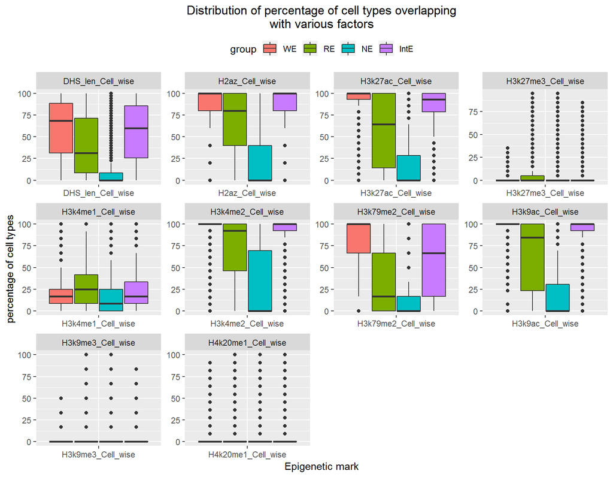

```r
descriptor(name = "OMICsdata",
factors = c("DHS_len_Cell_wise",
"H2az_Cell_wise","H3k27ac_Cell_wise","H3k27me3_Cell_wise",
"H3k4me1_Cell_wise","H3k4me2_Cell_wise",
"H3k79me2_Cell_wise","H3k9ac_Cell_wise", "H3k9me3_Cell_wise",
"H4k20me1_Cell_wise"),
groups = c("WE","RE","NE","IntE"),
choice = 1, title = "Distribution of percentage of cell types overlapping
with various factors")
```

In `choice` = 2, a value needs to be supplied to the argument `choice2group`. This value should be the name of one of the groups created by “create_group()”. The plot displayed in this mode represents the distribution of the percentage of celll lines corresponding to a factor/Assay/modality with various combination of other Assays/factors/modalities supplied through `factors`.

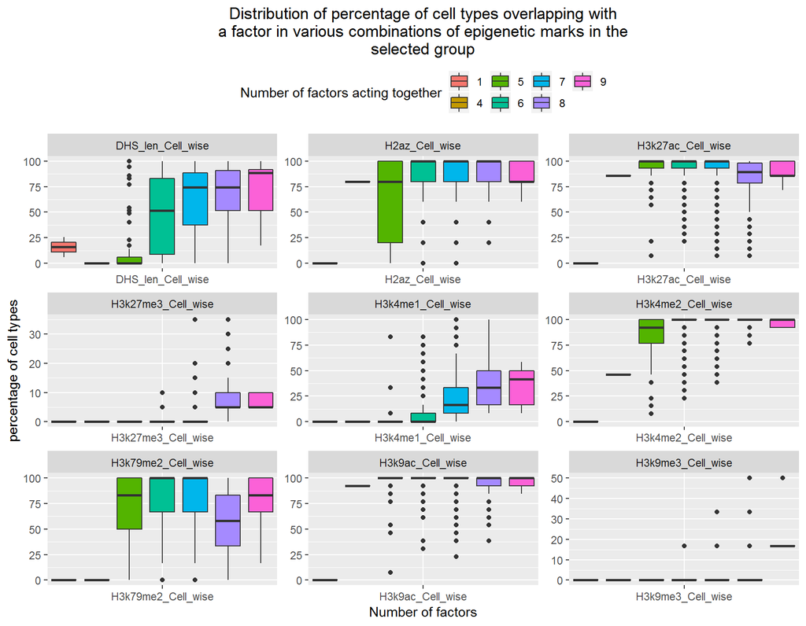

```r
descriptor(name = "OMICsdata",
factors = c("DHS_len_Cell_wise",
"H2az_Cell_wise","H3k27ac_Cell_wise","H3k27me3_Cell_wise",
"H3k4me1_Cell_wise","H3k4me2_Cell_wise",
"H3k79me2_Cell_wise","H3k9ac_Cell_wise", "H3k9me3_Cell_wise",
"H4k20me1_Cell_wise"), groups = c("WE","RE", "IntE","NE"),
choice = 2,
choice2group = "WE",
title = "Distribution of percentage of cell types overlapping with
a factor in various combinations of epigenetic marks in the
selected group")
```

### 3.4.2 chart_correlation()

This function creates pairwise correlation and scatter plots and histogram on selected groups. The type of results should be passed through the argument `choice`. This is a wrapper function on various functions and thus can take additional and non-conflicting arguments specific to them.

Summary of choices

| choice | functions | output |
| --- | --- | --- |
| table | cor {stats} | correlation table |
| scatter | pairs {graphics} | scatterplot of each pair |
| hist | ggplot,geom_histogram,facet_wrap{ggplot2} | histogram of each column |
| all | chart.Correlation {PerformanceAnalytics} | all of the above together |

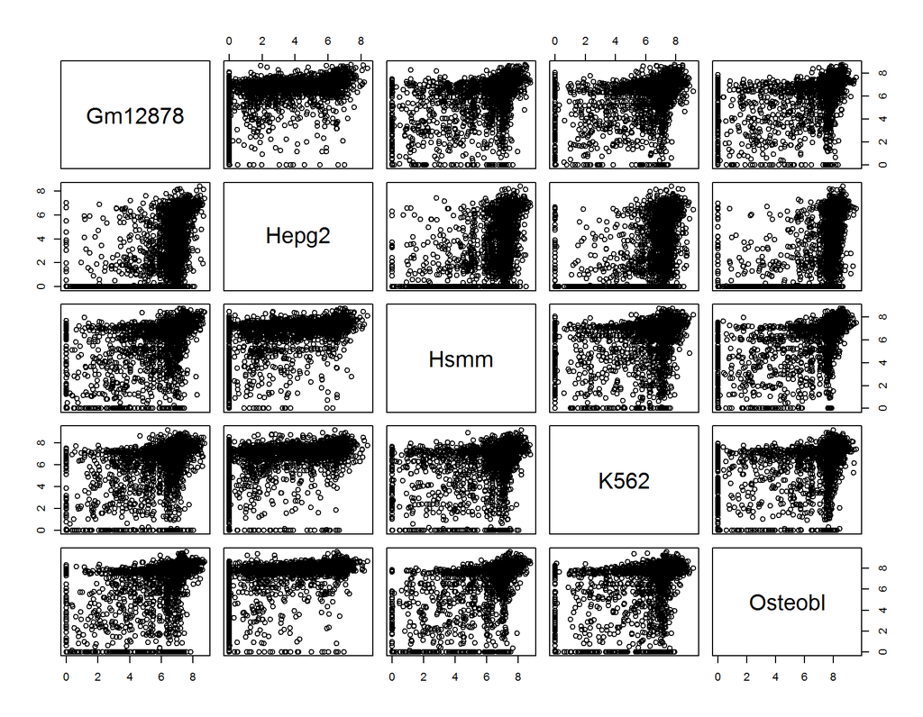

```r
groups <- c("WE")
chart_correlation(name = "OMICsdata", Assay = "H2az_Cell_wise",
groups = "WE", choice = "scatter")
```

All the correlation scatterplots of TSSs in “WE” looks similarly shaped except the ones coming from Hepg2. This is an indication that H2az pattern of the expression group “WE” is different in Hepg2 than other 4 cell lines.

The correlation value between each pair of cell lines may be calculated by `choice` = table. The slight difference in Hepg2 is visible here also.

```r
chart_correlation(name = "OMICsdata", Assay = "H2az_Cell_wise",
groups = "WE", choice = "table")
#           Gm12878     Hepg2      Hsmm      K562   Osteobl
# Gm12878 1.0000000 0.4631833 0.5542564 0.5637424 0.5693692
# Hepg2   0.4631833 1.0000000 0.4421005 0.4324214 0.4609538
# Hsmm    0.5542564 0.4421005 1.0000000 0.5003985 0.6742468
# K562    0.5637424 0.4324214 0.5003985 1.0000000 0.5058489
# Osteobl 0.5693692 0.4609538 0.6742468 0.5058489 1.0000000
```

The diversion of hepg2 is more evident when plotted as a histogram. The mode of “WE” is close to 0 in Hepg2 compared to other cell lines. This indicates that most of the “WE” in Hepg2 do not have H2az marks on them.

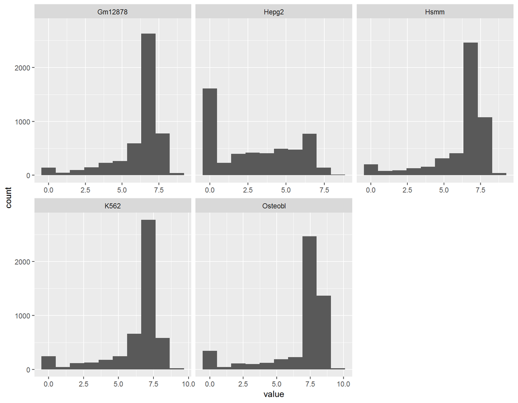

```r
chart_correlation(name = "OMICsdata", Assay = "H2az_Cell_wise",
groups = "WE", choice = "hist", bins = 10)
```

All the above 3 plots can be plotted in a single plot

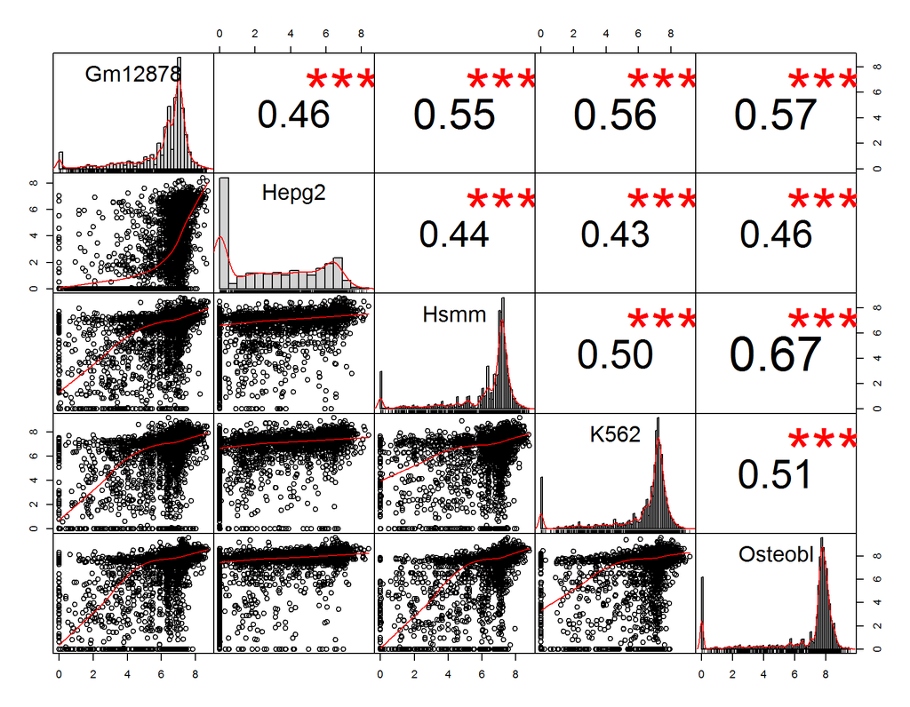

```r
chart_correlation(name = "OMICsdata", Assay = "H2az_Cell_wise",
groups = "WE", choice = "all")
```

## 3.5 Integration of Multiple Cell lines

If an assay (e.g. ChIP-seq for the histone modification of type H3k9ac) is done on multiple cells/conditions/treatment/time, it might be, sometimes, necessary to integrate or combine them, in order to understand the source of variation or to calculate a common metric to be served as the representative of all variables etc. Such a combination may be done by several techniques like Principal Component Analysis (PCA) or Factor Analysis (FA). OMICsPCA has a function **integrate_variables()** to integrate data from multiple cells or conditions using PCA.

*integrate_variables()* takes 3 mandatory inputs:

1. **factor**: name of data frames similar to the ones created by *prepareDataset()*.

An example of such a data frame is given below:

```r
head(H3k4me1_Cell_wise[177:179,1:5])
# # A tibble: 3 x 5
#   Gm12878 H1hesc  Hmec  Hsmm Hsmmt
# *   <dbl>  <dbl> <dbl> <dbl> <dbl>
# 1    0      0     0     0     0
# 2    0      0     0     0     0
# 3    5.37   6.76  7.39  7.84  7.49
```

*integrate_variables()* subsets the input dataframe into another dataframe according to the `groups` argument and integrates all columns of the sub data frame using PCA. This function is a wrapper around the function PCA() from package FactoMineR and thus can take additional arguments specific to the function PCA()

In this example, we supply two more additional arguments **scale.unit = FALSE** and **graph = FALSE**

The combined data is stored in the PCA slot of the “OMICs” object.

```r
integrate_variables(Assays = c("H2az_Cell_wise","H3k4me1_Cell_wise",
"H3k9ac_Cell_wise"), name = "OMICsdata",
groups = c("WE","RE", "NE", "IntE"), scale.unit = FALSE, graph = FALSE)
```

## 3.6 Analysis of integrated data

The **analyse_vaiables()** function is designed for a quick analysis and visualization of the data integrated by integrate() function. It takes 3 compulsory arguments **1) name**, **2) Assay** and **3) choice**. The type of analysis should be selected through the `choice` argument. This function acts as a wrapper around a collection of functions of package “factoextra” and “corrplot” and thus can take additional arguments specific and non-conflicting to such functions. Types of analysis and their corresponding input in `choice` are listed below:

**Note:** `PC` argument is mandatory for `choice` 4 and 5. (PC = principal component)

**Note:** User may use the functions listed below directly to supply more graphical parameters (e.g. `ncp` in choice 1, i.e. in fviz_eig, to restrict the display of the number of dimensions or use `select.var` in choice 2 to select columns/variables/cell lines satisfying some condition.). use `?` followed by the function name listed in the above table to explore more options available for each choice of “analyse_variables()”.

available choices

| choice | graphical output | console output | function used | package | additional arguments |
| --- | --- | --- | --- | --- | --- |
| 1 | Barplot of variance explained by each principal component (PC) or dimension | Table of eigen values and corresponding variance | fviz_eig | factoextra | addlabels |
| 2 | Loadings (in terms of cos2, contrib or coord supplied through the argument var_type) of columns/variables (cell lines in this example) on PC1 and PC2 | Table of loadings in terms of coord, cos2 or contrib as supplied through the argument var_type | fviz_pca_var | factoextra | var_type |
| 3 | Matrix plot of correlations of each column/variable (Cell line in this example) with each PC | Table of correlations of variables (Cell lines) with PCs/Dimensions | corrplot | factoextra and corrplot | is.corr |
| 4 | Barplot of squarred loadings (or cos2) of each column/variable (cell line in this example) on the PC/dimension of choice | Table of squarred loadings/cos2 of each variable (Cell line) on the PCs/ Dimensions | fviz_cos2 | factoextra | PC |
| 5 | The contributions of each column/variable (cell line in this example) in accounting for the variability in a given PC/dimension. The contribution (in percentage) is calculated as : squared loading of … | Table of contribution of each variable on the selected PC/Dimension | fviz_contrib | factoextra | PC |
| 6 | Variance explained by each of the first few PCs together with barplot explaining total variance explained by the displayed PCs in each assay | None | ggplot, plot_grid | ggplot2, cowplot | various graphical arguments to ggplot2 and cowplot functions |

Here are some examples of different choices:

### 3.6.1 choice = 1

Barplot of variance explained by each principal component (PC) or dimension

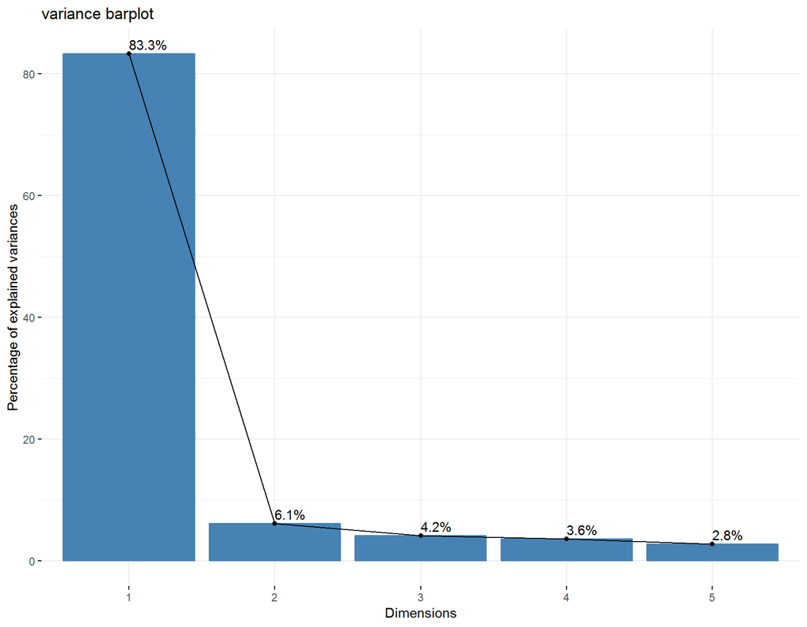

```
#       eigenvalue variance.percent cumulative.variance.percent
# Dim.1  35.779393        83.305644                    83.30564
# Dim.2   2.639572         6.145752                    89.45140
# Dim.3   1.787209         4.161183                    93.61258
# Dim.4   1.541631         3.589401                    97.20198
# Dim.5   1.201736         2.798019                   100.00000
```

```r
analyse_variables(name = "OMICsdata", Assay = "H2az_Cell_wise", choice = 1,
title = "variance barplot", addlabels = TRUE)
```

83.3 % of variation is captured by PC1 alone, which indicates that 5 cell lines are very similar to one another. However, there may be the influence of the huge number of “NE” (see integrate_variables() step). Therefore doing this analysis might be worth on each individual expression group.

### 3.6.2 choice = 2

```r
analyse_variables(name = "OMICsdata", Assay = "H3k4me1_Cell_wise",choice = 2,
title = "Loadings of cell lines on PC1 and PC2", xlab = "PCs")
```

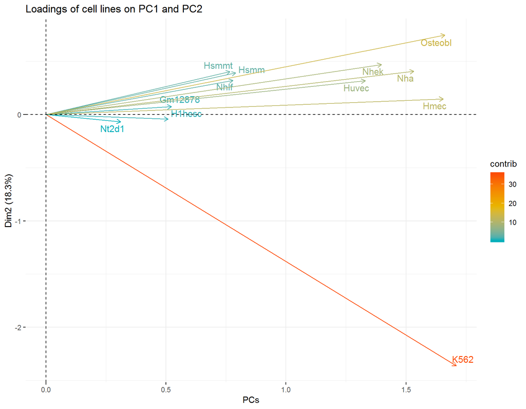

```
#              Dim.1       Dim.2       Dim.3      Dim.4      Dim.5
# Gm12878  1.6122501  0.07547622  0.36835090  2.4284811 51.4717421
# H1hesc   1.5266506  0.02547903  0.53455825  1.4913785  2.6823855
# Hmec    16.1611363  0.30279710 33.70752633  3.2831916  1.6894946
# Hsmm     3.6874185  2.15453027  0.07828379 11.7724181  2.1749222
# Hsmmt    3.4691140  2.28192948  0.18369298 16.9958418  3.6659963
# Huvec   10.4436967  1.41658682 16.19028015 50.5689254 12.8392675
# K562    17.2569846 78.93580791  1.00403525  0.6481982  0.2682735
# Nha     13.8628626  2.33736031  2.44025845  0.5796352  0.5178672
# Nhek    11.5221725  3.09780299 26.27831808  2.4563523  0.6874715
# Nhlf     3.5818397  1.45169741  0.35898153  5.3904567  0.7152927
# Osteobl 16.3047489  7.85274807 18.54098951  2.3396086 21.6769279
# Nt2d1    0.5711254  0.06778439  0.31472477  2.0455125  1.6103591
#                Dim.6        Dim.7       Dim.8       Dim.9       Dim.10
# Gm12878 40.315062978  0.106080569  2.80435698  0.60963169 2.014637e-01
# H1hesc   0.828927010 23.530092377 27.87809070 23.00036062 3.597760e+00
# Hmec     0.483017979  5.251661572 31.11659053  7.94529318 4.828593e-02
# Hsmm     8.809164528  4.696128343  0.63685688  0.00421789 1.969276e+00
# Hsmmt   15.751292720 11.527108397  1.81117415  0.63102455 2.294400e+01
# Huvec    5.489527201  1.419317375  0.02773966  1.51420176 4.444542e-02
# K562     0.008995178  1.549245247  0.03621791  0.18588650 1.631878e-04
# Nha      1.463454402 31.030361269  0.02063827 44.27677390 2.799019e+00
# Nhek     1.943600174 17.543335233 29.75569789  6.61326787 7.677415e-02
# Nhlf     1.776931840  0.004438558  0.06598961  0.17687757 6.421933e+01
# Osteobl 22.348353163  0.948431674  0.02381584  9.53974191 2.355337e-01
# Nt2d1    0.781672826  2.393799388  5.82283157  5.50272257 3.863944e+00
#               Dim.11       Dim.12
# Gm12878  0.005936925 1.166628e-03
# H1hesc  14.559723336 3.445938e-01
# Hmec     0.001014659 9.990303e-03
# Hsmm     0.089383167 6.392740e+01
# Hsmmt    0.002172222 2.073665e+01
# Huvec    0.044402812 1.609120e-03
# K562     0.103230182 2.962405e-03
# Nha      0.670878054 8.912644e-04
# Nhek     0.005607470 1.959976e-02
# Nhlf     7.761651267 1.449651e+01
# Osteobl  0.175006347 1.409443e-02
# Nt2d1   76.580993559 4.445297e-01
```

Loadings of each variable (here the cell lines) explain the intensity of their correlation with principal components. Each Cell line(variable) has a loading on each principal components, which is calculated as: **Loadings = Eigenvectors x sqrt(Eigenvalues)**.

In the above plot, the loading is expressed as the contribution of each cell lines on PC 1 and 2. Although the contribution of K562 is very high in PC1, its direction indicates its strong correlation with other PCs (PC2). On the other hand, Hmec, Huvec, Nha, Nhek and Osteobl are highly correlated only with PC1. The small value (hence the small arrows) of the contribution of other cell lines with PC1 indicates they might be correlated with other PCs also. This is more clearly explained when the plot is studied with the table generated by this command simultaneously.

### 3.6.3 choice = 3

As explained in “chart_correlation()”, Hepg2 is slightly different than other cell lines, and this is evident in the correlation plot also.

```r
analyse_variables(name = "OMICsdata", Assay = "H2az_Cell_wise",choice = 3,
title = "Correlation matrix", xlab = "PCs")
```

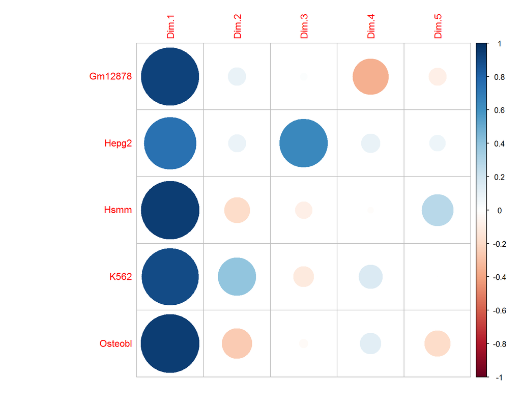

```
#             Dim.1       Dim.2       Dim.3       Dim.4         Dim.5
# Gm12878 0.9257715  0.09106662  0.01566028 -0.35624071 -0.0866104415
# Hepg2   0.7485728  0.08655067  0.64588121  0.09860930  0.0725360565
# Hsmm    0.9401016 -0.18374599 -0.08173410 -0.01104782  0.2750341646
# K562    0.8968137  0.39775752 -0.11549647  0.15548198 -0.0001868809
# Osteobl 0.9418103 -0.25031371 -0.02302760  0.12489507 -0.1849523974
```

### 3.6.4 choice = 4

This choice depicts the message interpreted above more clearly.

```r
analyse_variables(name = "OMICsdata", Assay = "H2az_Cell_wise", choice = 4,
PC = 1, title = "Squarred loadings of Cell lines on PC1")
#             Dim.1       Dim.2        Dim.3        Dim.4        Dim.5
# Gm12878 0.8570528 0.008293130 0.0002452444 0.1269074424 7.501369e-03
# Hepg2   0.5603612 0.007491018 0.4171625418 0.0097237942 5.261479e-03
# Hsmm    0.8837911 0.033762589 0.0066804629 0.0001220544 7.564379e-02
# K562    0.8042748 0.158211041 0.0133394357 0.0241746449 3.492447e-08
# Osteobl 0.8870066 0.062656956 0.0005302702 0.0155987778 3.420739e-02
```

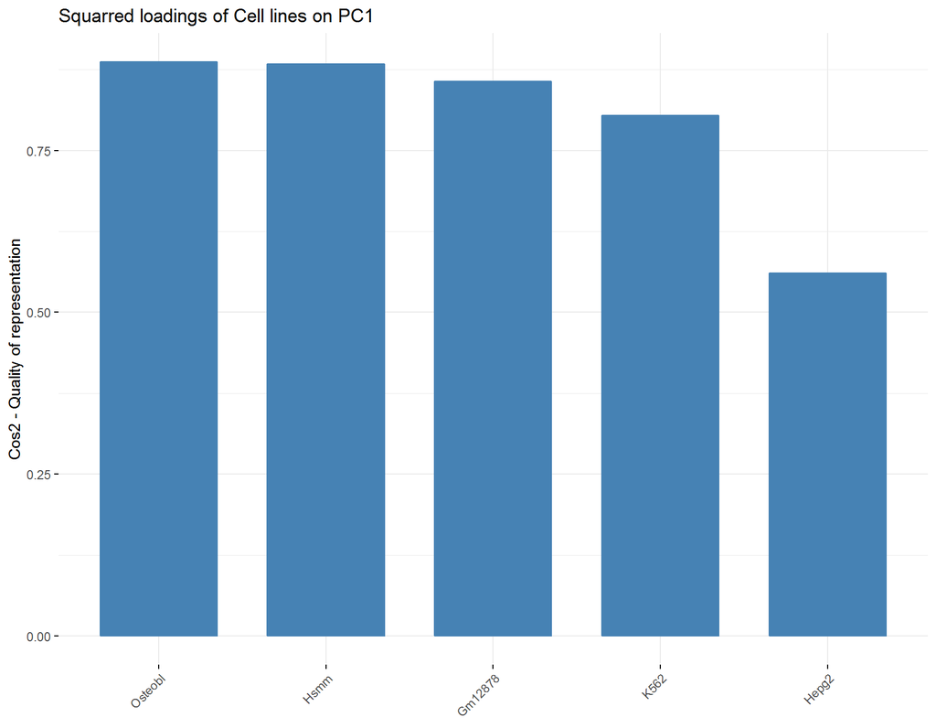

### 3.6.5 choice = 5

The contribution (in percentage) is calculated as: squared loading of the variable(e.g. a cell line) * 100 / total squared loading of the given PC/dimension. This is another way to represent similar message we got from choice 2

```r
analyse_variables(name = "OMICsdata", Assay = "H2az_Cell_wise", choice = 5,
PC=1, title = "Contribution of Cell lines on PC1")
```

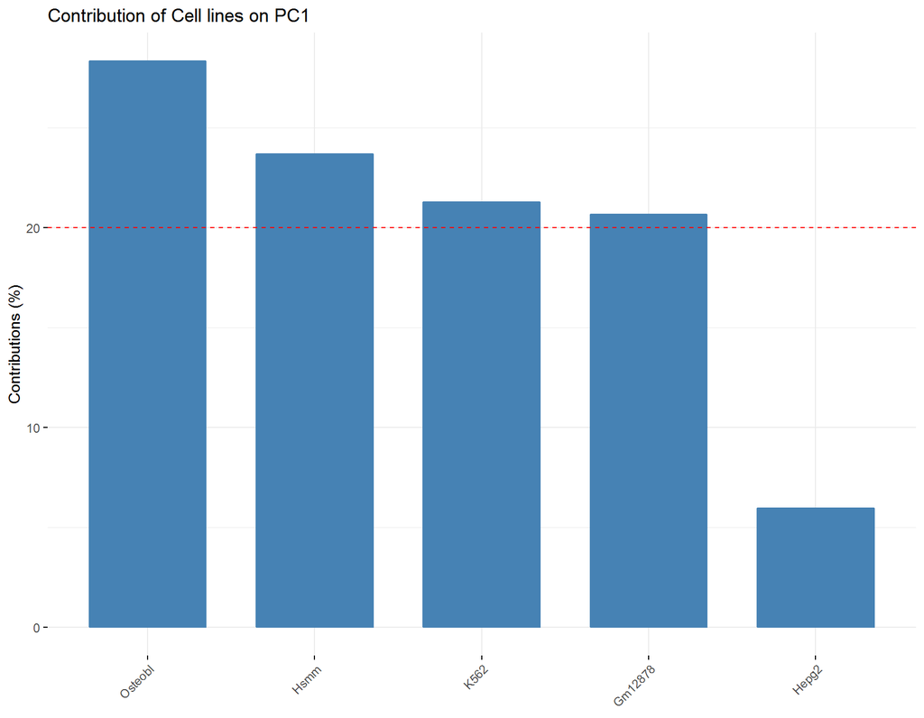

```
#             Dim.1     Dim.2      Dim.3       Dim.4        Dim.5
# Gm12878 20.686358  2.713278  0.1185040 71.09121587 5.390644e+00
# Hepg2    5.964017  1.080715 88.8860882  2.40192278 1.667257e+00
# Hsmm    23.693083 12.268941  3.5853877  0.07594124 6.037665e+01
# K562    21.294342 56.780069  7.0705762 14.85498595 2.753045e-05
# Osteobl 28.362200 27.156997  0.3394438 11.57593416 3.256542e+01
```

### 3.6.6 choice = 6

Percentage of variance explained by principal components in all the selected assays. The number of PCs is automatically reduced to the column dimension of the assay having the least number of cell lines (and thus least number of PCs or dimensions)

```r
analyse_variables(name = "OMICsdata", Assay = c("H3k9ac_Cell_wise",
"H2az_Cell_wise","H3k4me1_Cell_wise"),
choice = 6)
# Using PC as id variables
```

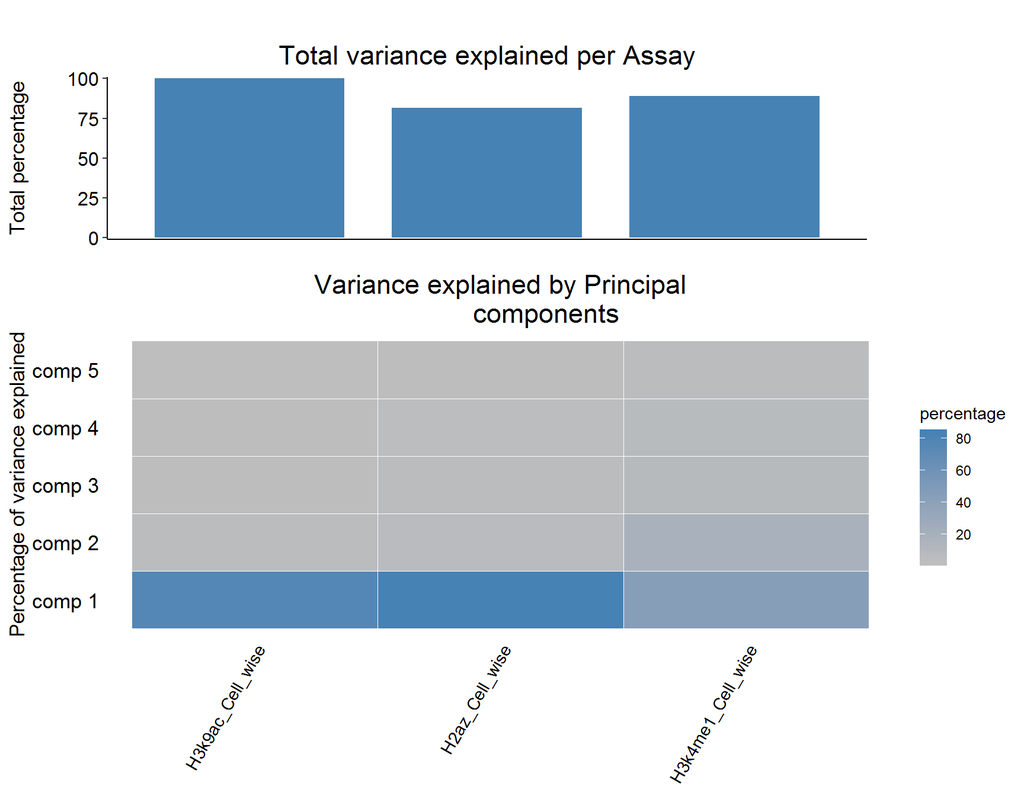